# Exam_SVM_RF_NN

# SVM

Предположим, что присутствует линейная разделимость, т.е. существует гиперплоскость

(определяемая уравнением $\boldsymbol{x}^{T}\boldsymbol{w}-w_0=0$ ($\boldsymbol{x},\boldsymbol{w}\in\mathbb{R}^p; w_0\in\mathbb{R}$).

Как и прежде у нас есть линейный классификатор: $$f\left(\boldsymbol{x}_i\right)=sign\left(\langle\boldsymbol{x}_i,\boldsymbol{w}\rangle -w_0\right),$$ где $\boldsymbol{x},\boldsymbol{w}\in\mathbb{R}^p; w_0\in\mathbb{R}$.

И кусочно линейна функция потерь, где $M_i=-\langle (\boldsymbol{w}, \boldsymbol{x}_i),\boldsymbol{x}_i\rangle y_i$: $$L(M_i)=\max\{0,1+M_i\}$$

Факт принадлежности наблюдений из разных классов разным полупространствам можно описать уравнением: $$ (\boldsymbol{x}^{T}\boldsymbol{w}-w_0) y_i > 0 $$ В таком случае, классифицирующим правилом разумно принять $f\left(x\right)=sign{\left(\boldsymbol{x}^{T}\boldsymbol{w}-w_0\right)}$

Может существовать более одной гиперплоскости, разделющий данные. Вводим понятие зазора (margin), критерий оптимальности: максимальный зазор.

С точностью до нормировки вектора $\boldsymbol{w}$ эта пара гиперплоскостей может быть описана парой уравнений: $$ \begin{cases} \boldsymbol{x}^{T}\boldsymbol{w}-w_0 = -1 \\ \boldsymbol{x}^{T}\boldsymbol{w}-w_0 = 1 \\ \end{cases} $$

Решая задачу квадратичного программирования

$$ \begin{cases} \frac{1}{2}\langle\boldsymbol{w},\boldsymbol{w}\rangle\rightarrow \min\limits_{\boldsymbol{w} }\\ \left(\langle\boldsymbol{x}_i,\boldsymbol{w}\rangle - w_0\right)y_i \geq 1 \\ \end{cases} $$

В точке оптимума выполнены условия Каруша-Куна-Такера, в частности: $$ \alpha_i \left[1-y_i\left(\langle\boldsymbol{x}_i,\boldsymbol{w}\rangle - w_0\right)\right] = 0\, \forall i$$

1. $\alpha_i=0$ т.е. наблюдение не влияет на $\boldsymbol{w},w_0$
2. $\alpha_i>0 \Rightarrow y_i \left(\langle\boldsymbol{x}_i,\boldsymbol{w}\rangle - w_0\right) = 1$ -- такое наблюдение будем называть опорным вектором

Поскольку в случае линейно неразделимой выборки по определению любой линейный классификатор будет ошибаться, условие $\left(\langle\boldsymbol{x}_i,\boldsymbol{w}\rangle - w_0\right)y_i \geq 1$ не может быть выполнено для всех $i$. Введём ошибки $\xi \geq 0$ алгоритма и штрафы за эти ошибки в минимизируемую функцию следующим образом: $$ \begin{cases} \frac{1}{2}\langle\boldsymbol{w},\boldsymbol{w}\rangle+C\sum\limits_{i=1}^n\xi_i\rightarrow \min\limits_{\boldsymbol{w},w_0 }\\ \left(\langle\boldsymbol{x}_i,\boldsymbol{w}\rangle - w_0\right)y_i \geq 1 -\xi_i\\, \end{cases}$$ где C задает размер штрафа за ошибки.

SVM в нелинейном случае:

Пусть $\phi (\boldsymbol{x}_i)$ - спрямляющее отображение. Тогда, можем записать SVM в спрямляющем отображении, используя следующее скалярное произведение: $$ \boldsymbol{x}_i \rightarrow \phi (\boldsymbol{x}), ~ \boldsymbol{w} \rightarrow \phi (\boldsymbol{w}), ~ \langle \boldsymbol{w}, \boldsymbol{x}_i \rangle \rightarrow \langle \phi (\boldsymbol{w}), \phi (\boldsymbol{x}_i) \rangle$$

Чтобы получить нелинейную разделимость в исходном пространстве - зададим скалярное произведение следующего вида: $$K(\boldsymbol{w}, \boldsymbol{x}_i) = \langle \phi (\boldsymbol{w}), \phi (\boldsymbol{x}_i) \rangle$$ $K$ - симметричная нелинейная функция

Линейное ядро: $$K(\boldsymbol{w}, \boldsymbol{x}_i) = \langle \boldsymbol{w}, \boldsymbol{x}_i \rangle$$

Полиномиальное ядро: $$K(\boldsymbol{w}, \boldsymbol{x}_i) = (\langle \boldsymbol{w}, \boldsymbol{x}_i \rangle + r)^d$$

Радиальное ядро: $$K(\boldsymbol{w}, \boldsymbol{x}_i) = exp(-\gamma ||(\boldsymbol{w}-\boldsymbol{x}_i)||^2)$$

Сигмовидное ядро: $$K(\boldsymbol{w}, \boldsymbol{x}_i) = tahn(\gamma x^Ty+c_0)$$

Будем искать параметры SVM по сетке, перебирая ядра, параметры регуляризации, степень (только для полиномиального ядра) и коэфициент сдвига (для полиномиального и сигмаидального). По умолчанию gamma = 1 / (n_features * X.var()).

```python
GRID = [
    {'estimator': [svm.SVC()],
     'estimator__kernel': ['linear', 'poly', 'rbf', 'sigmoid'],
     'estimator__C': [1, 5, 10],
     'estimator__degree': [3, 4],
     'estimator__coef0': [0, 1, 5, 10],
     }
]
PIPELINE = Pipeline([('scaler', StandardScaler()), ('estimator', svm.SVC())])
grid_search_SVM = GridSearchCV(estimator=PIPELINE, param_grid=GRID,
                            scoring=make_scorer(f1_score , average='micro'),
                            n_jobs=-1, cv=3, refit=True, verbose=2,
                            return_train_score=True)
```

```python
random.seed(1)
grid_search_SVM.fit(X_train.values, y_train)
```

```
Fitting 3 folds for each of 96 candidates, totalling 288 fits
```

```
GridSearchCV(cv=3,
             estimator=Pipeline(steps=[('scaler', StandardScaler()),
                                       ('estimator', SVC())]),
             n_jobs=-1,
             param_grid=[{'estimator': [SVC(C=5, coef0=5, kernel='poly')],
                          'estimator__C': [1, 5, 10],
                          'estimator__coef0': [0, 1, 5, 10],
                          'estimator__degree': [3, 4],
                          'estimator__kernel': ['linear', 'poly', 'rbf',
                                                'sigmoid']}],
             return_train_score=True,
             scoring=make_scorer(f1_score, average=micro), verbose=2)
```

```python
print(grid_search_SVM.score(X_train.values, y_train))
print(grid_search_SVM.best_params_)
```

```
0.7830822711471611
{'estimator': SVC(C=5, coef0=5, kernel='poly'), 'estimator__C': 5, 'estimator__coef0': 5, 'estimator__degree': 3, 'estimator__kernel': 'poly'}
```

```python
print("Test set score: %f" % grid_search_SVM.score(X_test.values, y_test))
```

```
Test set score: 0.771084
```

На тестовом 77%

```python
Y_pred = grid_search_SVM.predict(X_test.values)
```

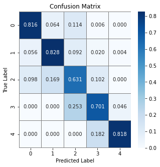

```python
confusion_mtx = confusion_matrix(Y_pred, y_test, normalize = 'true')
f,ax = plt.subplots(figsize=(5, 5))
sns.heatmap(confusion_mtx, annot=True, linewidths=0.01,cmap="Blues",linecolor="gray", fmt= '.3f',ax=ax)
plt.xlabel("Predicted Label")
plt.ylabel("True Label")
plt.title("Confusion Matrix")
plt.show()
```

# Random Forest

Дерево решений:

Пусть $\mathbf X\in\mathbb R^{n\times k}$-- матрица данных, $n$-- число индивидов, $k$-- число признаков, $Y\in\mathbb R^n$-- вектор отклика, $X_i$-- вектор признака, $i\in1:k$.

Дерево решений-- бинарное дерево $(V,E)$, в котором каждой $v\in V$, не являющейся листом соответствует функция, являющаяся предикатом $\beta_v:X\to\{0,1\}$, а каждому листу $l\in V$ соответствует прогноз $f_l:X\to Y$.

Обозначим за $p_{jk}$ долю объектов класса $c\in Y$ в многомерном прямоугольнике $R_j\in\mathbb R^p$ $$\widehat p_{jc}=\frac1{N_j}\sum\limits_{x_i\in R_j}{1}(y_i=c)$$ $\{R_j\}_{j=1}^J$-- решение оптимизационной задачи $$\mathrm{ME}=1-\max_{j,c}\widehat p_{jc}\to\min\limits_{R_1,\ldots,R_J}.$$ $\mathrm{ME}$ не является дифференцируемой функцией, поэтому используются другие функции:

```
Индекс Джини
```

$G(j)=\Sigma_{k=1}^K\widehat p_{jc}(1-\widehat p_{jc})$

```
Кросс-энтропия
```

$CI(j)=-\Sigma_{k=1}^K\widehat p_{jc}log\widehat p_{jc}$

Предсказание для объекта $x\in X$ равно

$$f(x)=argmax _{c\in Y}\widehat {p}_{ck},$$

где $j$-- индекс многомерного многоугольника, в который попадает $x$.

Bagging

Пусть у нас имеется набор из $n$ независивых наблюдений $X_1,\ldots X_n$, каждый из которых имеет дисперсию $\sigma^2$, дисперсия $\bar{X}$ будет равна $\sigma^2/n$. Другими словами, усреднение набора наблюдений снижает дисперсию.

Следовательно, естественный способ уменьшить дисперсию и, следовательно, увеличить точность предсказания статистического метода обучения заключается в том, чтобы взять множество обучающих наборов из выборки, построить отдельную модель предсказания, используя каждый набор обучения и усреднить полученные прогнозы.

\begin{equation} {a}_{N}(x) = \dfrac{1}{N}\sum_{n=1}^{N}\hat{\mu}(x) \end{equation}

Однако на практике это не реализовать, потому что у нас нет нескольких сетов обучающих данных. Вместо этого, мы можем примеить бутстрап беря несколько сэмплов из обучающего набора данных. При таком подходе, мы генерируем $B$ разных подвыборок с помощью бутсрапа. Затем мы обучаем модель на $b$-ом сете обучающих данных и усредняем прогнозы.

Это называется бэггингом.

Алгоритм Random Forest:

Для $n=1,\ldots,N$

1. Сгенерировать выборку $\hat{X}_n$ с помощью бутстрапа.
2. Построить решающее дерево $b_n(x)$ по выборке $\hat{X}_n$. дерево строится, пока в каждом листе не окажется не более $n_{min}$ объектов

   ```
    при каждом разбиении сначала выбирается $m$ случайных признаков из $p$ и оптимальное разделение ищется только среди них
   ```

3. Вернуть композицию $a_N(x) = \dfrac{1}{N}\sum_{n=1}^{N}b_n(x)$

Будем искать параметры RF по сетке, перебирая количество деревьев в лесу, функции потерь, максимальную глубину дерева и функции определения количества индивидов, bootstrap, минимальное количество индивидов после деления, минимальное количество индивидов необходимое для деления.

```python
n_estimators = [int(x) for x in np.linspace(start = 100, stop = 500, num = 4)]
max_features = ['log2', 'sqrt']
max_depth = [int(x) for x in np.linspace(start = 4, stop = 50, num = 3)]
min_samples_split = [2, 5, 7]
min_samples_leaf = [2, 5, 7]
bootstrap = [True, False]
GRID = [
    {'estimator': [RandomForestClassifier()],
     'estimator__criterion': ['gini', 'entropy'],
     'estimator__n_estimators': n_estimators,
     'estimator__max_features': max_features,
     'estimator__max_depth': max_depth,
     'estimator__min_samples_split': min_samples_split,
     'estimator__min_samples_leaf': min_samples_leaf,
     'estimator__bootstrap': bootstrap
     }
]

PIPELINE = Pipeline([('scaler', StandardScaler()), ('estimator', RandomForestClassifier())])
```

```python
grid_search_RF = GridSearchCV(estimator=PIPELINE, param_grid=GRID,
                            scoring=make_scorer(f1_score , average='micro'),
                            n_jobs=-1, cv=3, refit=True, verbose=2,
                            return_train_score=True)
```

```python
random.seed(1)
grid_search_RF.fit(X_train.values, y_train)
```

```
Fitting 3 folds for each of 864 candidates, totalling 2592 fits
```

```
GridSearchCV(cv=3,
             estimator=Pipeline(steps=[('scaler', StandardScaler()),
                                       ('estimator',
                                        RandomForestClassifier())]),
             n_jobs=-1,
             param_grid=[{'estimator': [RandomForestClassifier(bootstrap=False,
                                                               max_depth=27,
                                                               min_samples_leaf=5,
                                                               min_samples_split=7,
                                                               n_estimators=366)],
                          'estimator__bootstrap': [True, False],
                          'estimator__criterion': ['gini', 'entropy'],
                          'estimator__max_depth': [4, 27, 50],
                          'estimator__max_features': ['log2', 'sqrt'],
                          'estimator__min_samples_leaf': [2, 5, 7],
                          'estimator__min_samples_split': [2, 5, 7],
                          'estimator__n_estimators': [100, 233, 366, 500]}],
             return_train_score=True,
             scoring=make_scorer(f1_score, average=micro), verbose=2)
```

```python
print(grid_search_RF.score(X_train.values, y_train))
print(grid_search_RF.best_params_)
```

[output not shown]

```python
print("Test set score: %f" % grid_search_RF.score(X_test.values, y_test))
```

```
Test set score: 0.759963
```

На тестовом 76%

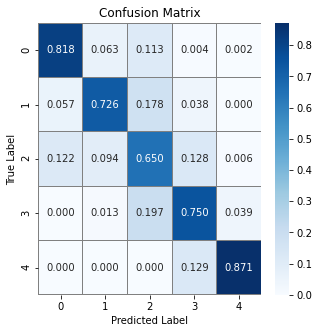

```python
Y_pred = grid_search_RF.predict(X_test.values)
confusion_mtx = confusion_matrix(Y_pred, y_test, normalize = 'true')
f,ax = plt.subplots(figsize=(5, 5))
sns.heatmap(confusion_mtx, annot=True, linewidths=0.01,cmap="Blues",linecolor="gray", fmt= '.3f',ax=ax)
plt.xlabel("Predicted Label")
plt.ylabel("True Label")
plt.title("Confusion Matrix")
plt.show()
```

# Neural Nets

Пусть $X$ --- множество объектов, $Y$ --- множество ответов. Пусть есть обучающая выборка $X^n = (x_i, y_i)_{i=1}^{n},$ $x_i \in \mathbb{R}^p$. Обозначим $(x^1,\ldots,x^p)\in \mathbb{R}^p$ --- вектор признаков объекта $x\in X$. Рассмотрим следующую задачу построения предсказывающей модели: \begin{equation*} Q(a, X^n) = \frac{1}{n} \sum_{i=1}^{n} \mathcal{L}(a,x_i,y_i) \rightarrow \min_w, \end{equation*} где предсказывающую функцию $a$ зададим следующим образом (рассмотрим особый класс функций): \begin{equation*} a(x, w) = \sigma( \langle w,x \rangle ) = \sigma\left(\sum_{j=1}^{p} w_j x^j - w_0 \right), \end{equation*} где $w_k \in \mathbb{R}$, $k=0,\ldots,p$ --- параметры; $\sigma: \mathbb{R} \rightarrow \mathbb{R} $ --- функция активации; $\mathcal{L}(a,x_i,y_i)$ --- функция потерь, $i=1,\ldots,n$.  
Задача классификации. Пусть $Y=\{+1,-1\}$. Если $\sigma (z)=sign (z)$, то $a(x,w)$ --- линейный классификатор, и задача выглядит следующим образом:  
\begin{equation*} Q(w, X^{n})=\sum_{j=1}^{n} \mathcal{L} \left( a(x_j ,w), y_j \right) = \sum_{j=1}^{n} [y_j \langle w,x_j \rangle < 0] \rightarrow \min_{w}. \end{equation*}

В качестве функций активации чаще всего используются следующие функции: Сигмоидная функция: $\sigma(z) = \frac{1}{1+e^{-a\,z}}$, $a \in \mathbb{R}$; Softmax: $SM_i(z) = \frac{e^{z_i}}{\sum_{k=1}^{K}e^{z_k}}$;

Гиперболический тангенс: $\sigma(z) = \frac{e^{a\,z} - e^{-a\,z}}{e^{a\,z} + e^{-a\,z}}$, $a \in \mathbb{R}$;

Выпрямитель: $ReLU(p) = \max (0,p)$;

Любую непрерывную функцию можно приблизить нейронной сетью с любой желаемой точностью. А также, что для этой сети требуется один скрытый слой и одна нелинейная функция активации.

Для улучшения сходимости применимы некоторые эвристики:

1. инициализация весов;
2. порядок предъявления объектов;
3. оптимизация величины градиентного шага;
4. регуляризация (сокращение весов).

```python
mlp = MLPClassifier(hidden_layer_sizes=(1000, 500, 300), activation='relu',
                    solver='adam',
                    alpha=1e-4, verbose=False, learning_rate_init=.0001, max_iter=1, warm_start=True, early_stopping = False)
mlp_score1 = np.array([])
mlp_score2 = np.array([])
X_train1, X_train2, y_train1, y_train2 = train_test_split(X_train, y_train, train_size=0.75, stratify=y_train)
```

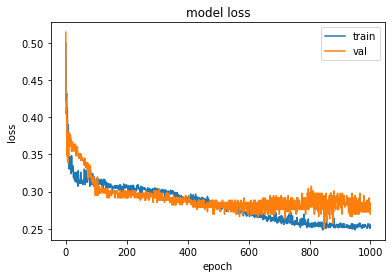

```python
for i in range(1000):
    mlp.fit(X_train1, y_train1)
    mlp_score1 = np.append(mlp_score1, mlp.score(X_train1, y_train1))
    mlp_score2 = np.append(mlp_score2, mlp.score(X_train2, y_train2))
plt.figure()
plt.plot(1 - mlp_score1)
plt.plot(1 - mlp_score2)
plt.title('model loss')
plt.ylabel('loss')
plt.xlabel('epoch')
plt.legend(['train','val'], loc = 'upper right')
plt.show()
```

Установим max_iter=500, так как дальше ошибки на train продолжают уменьшаться, а на val больше нет.

```python
GRID = [
    {'estimator': [MLPClassifier()],
     'estimator__solver': ['adam'],
     'estimator__learning_rate_init': [0.001],
     'estimator__max_iter': [500],
     'estimator__hidden_layer_sizes': [(1000, 200, 300, 5)],
     'estimator__activation': ['logistic', 'relu'],
     'estimator__alpha': [1e-2],
     'estimator__early_stopping': [True]
     }
]

PIPELINE = Pipeline([('scaler', StandardScaler()), ('estimator', MLPClassifier())])
```

```python
grid_search_NN = GridSearchCV(estimator=PIPELINE, param_grid=GRID,
                            scoring=make_scorer(accuracy_score),
                            n_jobs=-1, cv=2, refit=True, verbose=2,
                            return_train_score=True)
```

```python
random.seed(1)
grid_search_NN.fit(X_train.values, y_train)
```

```
Fitting 2 folds for each of 2 candidates, totalling 4 fits
```

```
GridSearchCV(cv=2,
             estimator=Pipeline(steps=[('scaler', StandardScaler()),
                                       ('estimator', MLPClassifier())]),
             n_jobs=-1,
             param_grid=[{'estimator': [MLPClassifier(alpha=0.01,
                                                      early_stopping=True,
                                                      hidden_layer_sizes=(1000,
                                                                          200,
                                                                          300,
                                                                          5),
                                                      max_iter=500)],
                          'estimator__activation': ['logistic', 'relu'],
                          'estimator__alpha': [0.01],
                          'estimator__early_stopping': [True],
                          'estimator__hidden_layer_sizes': [(1000, 200, 300,
                                                             5)],
                          'estimator__learning_rate_init': [0.001],
                          'estimator__max_iter': [500],
                          'estimator__solver': ['adam']}],
             return_train_score=True, scoring=make_scorer(accuracy_score),
             verbose=2)
```

```python
print(grid_search_NN.score(X_train.values, y_train))
print(grid_search_NN.best_params_)
```

```
0.029902642559109873
{'estimator': MLPClassifier(alpha=0.01, early_stopping=True,
              hidden_layer_sizes=(1000, 200, 300, 5), max_iter=500), 'estimator__activation': 'relu', 'estimator__alpha': 0.01, 'estimator__early_stopping': True, 'estimator__hidden_layer_sizes': (1000, 200, 300, 5), 'estimator__learning_rate_init': 0.001, 'estimator__max_iter': 500, 'estimator__sol…
```

```python
print("Test set score: %f" % grid_search_NN.score(X_test.values, y_test))
```

```
Test set score: 0.029657
```

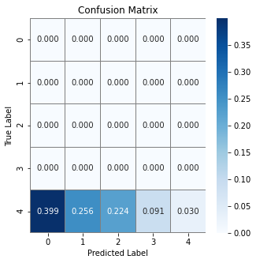

```python
Y_pred = grid_search_NN.predict(X_test.values)
confusion_mtx = confusion_matrix(Y_pred, y_test, normalize = 'true')
f,ax = plt.subplots(figsize=(5, 5))
sns.heatmap(confusion_mtx, annot=True, linewidths=0.01,cmap="Blues",linecolor="gray", fmt= '.3f',ax=ax)
plt.xlabel("Predicted Label")
plt.ylabel("True Label")
plt.title("Confusion Matrix")
plt.show()
```